# Survey32 Writeup

Survey 32 was given out to soldiers in 1943, approximately 5 years before the military was integrated. The survey was passed out to 7442 black soldiers and 4793 white soldiers and asked for basic demographic information, career aspirations, and more but of interests to us, Survey 32 asked the soldiers for their opinions on integration of military outfits.

```
##     age       edu      enlist   outfits        state  community
## 1   35+ 6TH GRADE VOLUNTEERED Seperated         <NA>       Farm
## 2 25-27 6TH GRADE     DRAFTED Seperated         <NA> Small Town
## 3 21-24 6TH GRADE     DRAFTED Seperated  CONNECTICUT       Town
## 4 30-34 6TH GRADE VOLUNTEERED Seperated PENNSYLVANIA       City
## 5 21-24 6TH GRADE     DRAFTED Seperated         OHIO       Farm
## 6 25-27 6TH GRADE     DRAFTED  Together   NEW MEXICO       Farm
```

```
##   age       edu      enlist   outfits    state  community
## 1  20 4TH GRADE VOLUNTEERED  Together MISSOURI Small Town
## 2  20 4TH GRADE VOLUNTEERED Seperated MISSOURI Large City
## 3  20 4TH GRADE VOLUNTEERED Seperated   KANSAS       City
## 4  20 4TH GRADE VOLUNTEERED Seperated NEBRASKA Small Town
## 5  20 4TH GRADE VOLUNTEERED Seperated     IOWA Large City
## 6  20 4TH GRADE VOLUNTEERED Seperated   KANSAS       Town
```

## Overview of Basic Demographic Variables

### How Old Are the Soldiers

Age was not collected on a continuous scale and was discretized into a few different age groups. We see that the overwhelming bulk of black soldiers who were survied were 20 years old with a small portion who were 19 or younger. In the meanwhile, the white soldiers had more spread to their ages with most soldiers being between the ages of 21 and 24.

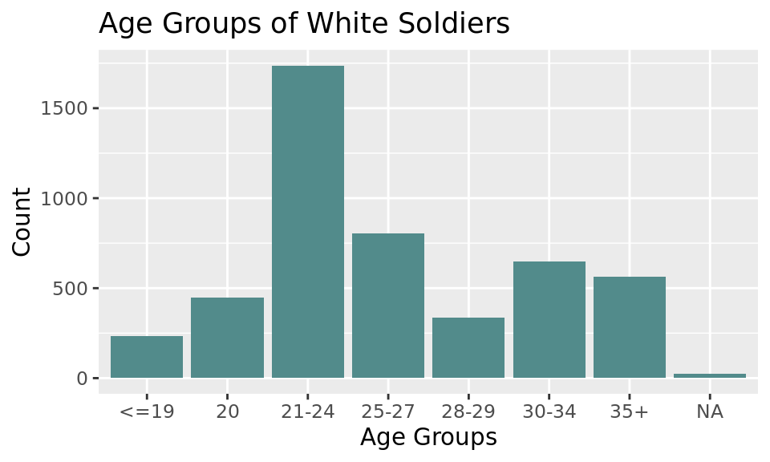

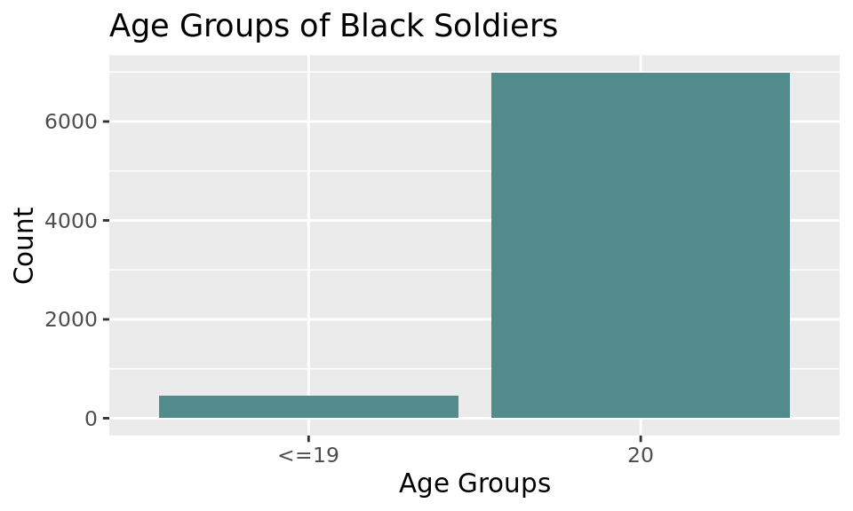

### How Far in School Were They?

If we look at education now we see that again black soldiers have littel spread in their education. Remarkably, all of the black soldiers survied have less than a 5th grade education at the time. Meanwhile, the bulk of the white soldiers have had a high school/some high school.

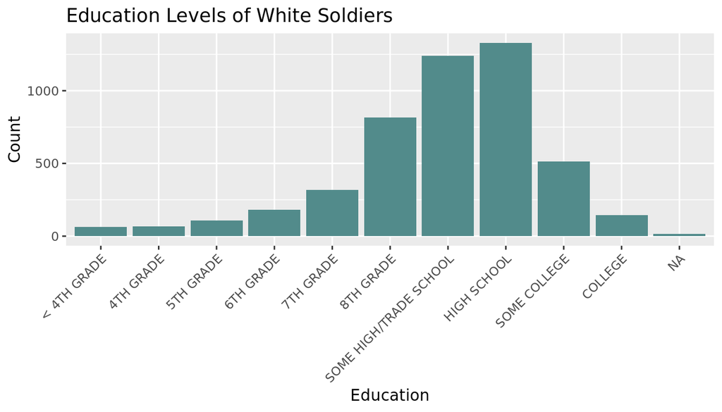

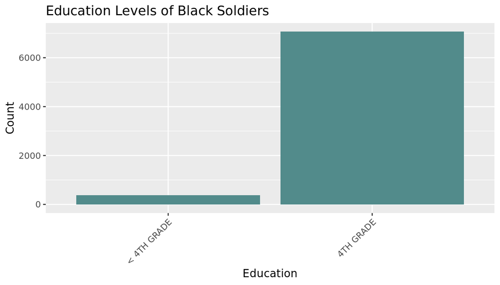

### How Did They End Up in the Military

Something interesting arises here were we find that vast majority of the black soldiers actually volunteered to join the military whereas about 3/4 of the survied white soldiers were drafted and the remaining soldiers were moslty volunteers and a few were from the National Guard.

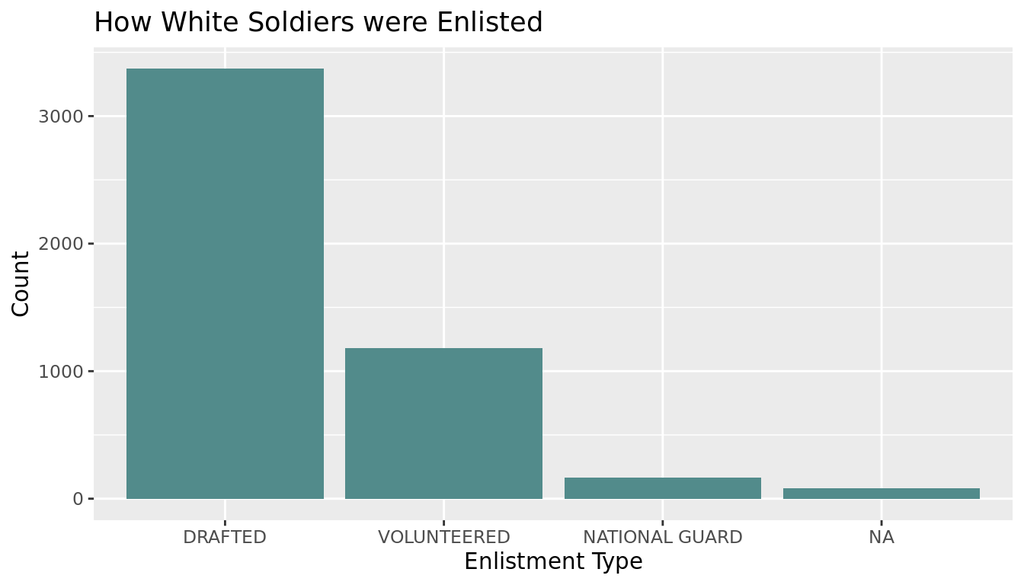

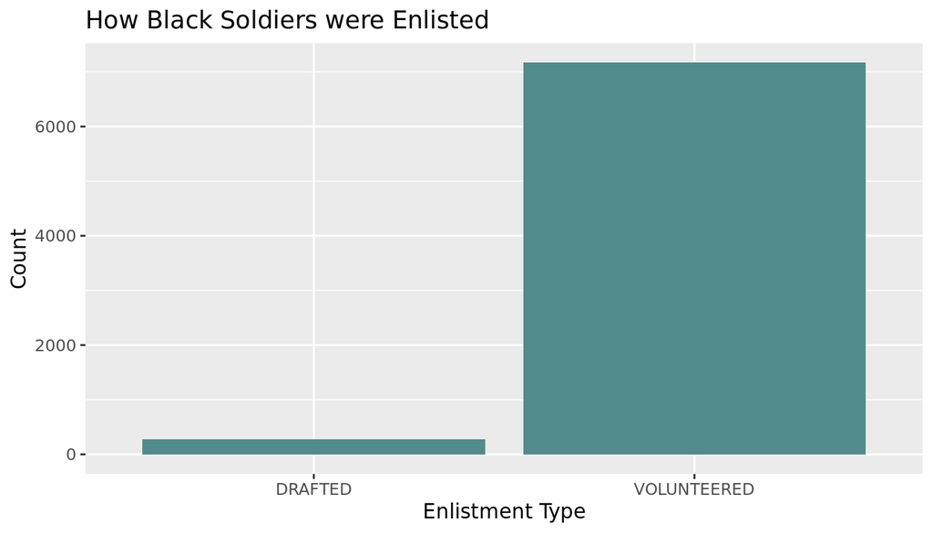

### Where Are the Soldiers From?

Expectedly, most of the soldiers hailed from the most populous states at the time. White soldiers were mostly from Illionois, Pennsylvania, Ney York, Texas, and Michigan while black soldiers were mostly from Texas, New York, Illinois, Pennsylvania, and Ohio. Note that the top 4 states for white soldiers had similar amounts of soldiers but there was a sever drop off in representation of black soldiers from other states after Texas and New York.

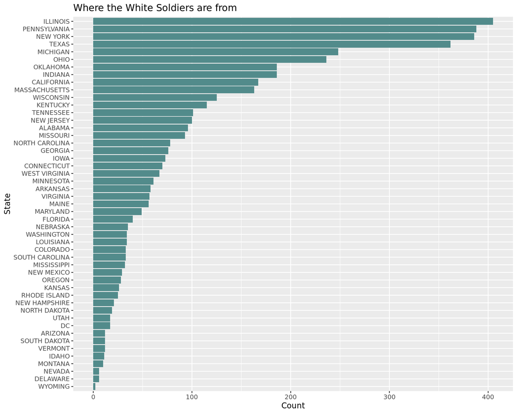

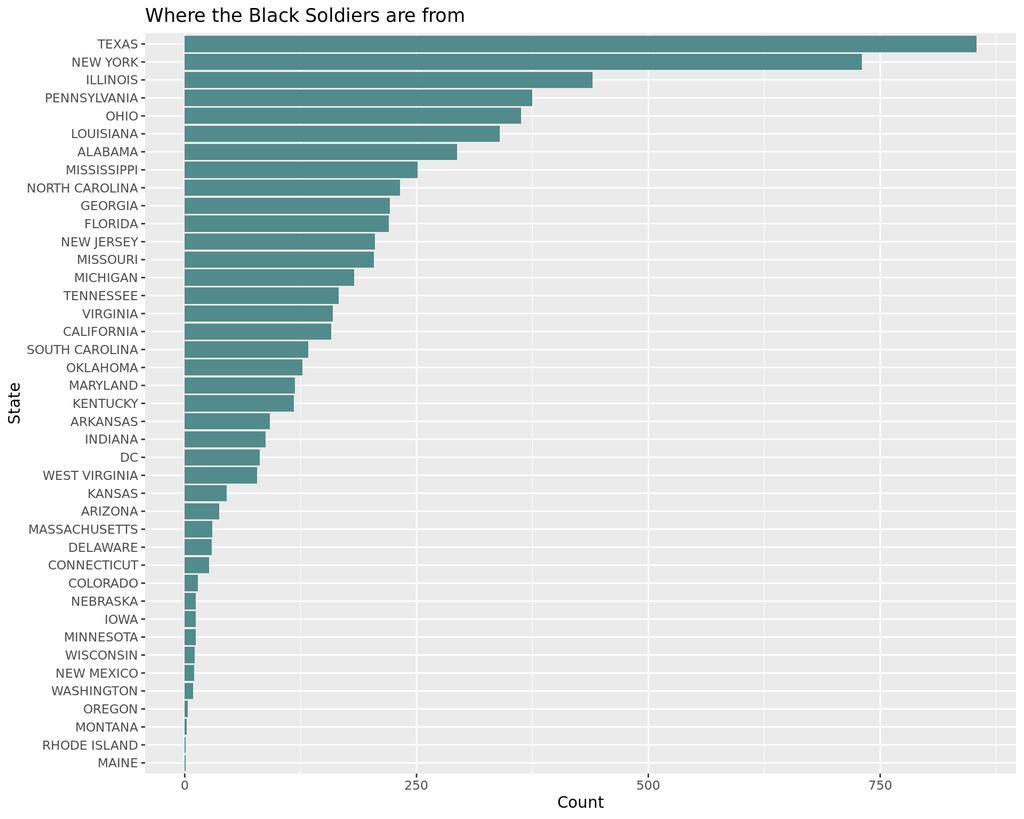

### What sort of places did they live in?

As expected, most soldiers whose home communities are large cities had the most representation across both groups. White soldiers saw roughly equal representation from soldiers who came from a farm, town, or city with actually slightly less people from cities. On the otherhand, the next community with the largest representation for black soldiers was a city followed by farms and towns which had approximately similar contributions.

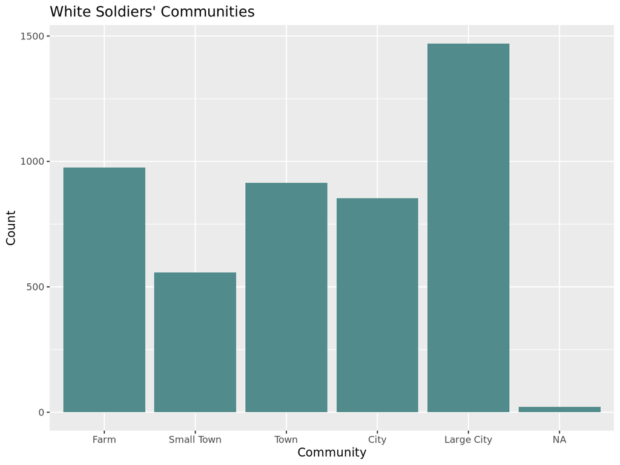

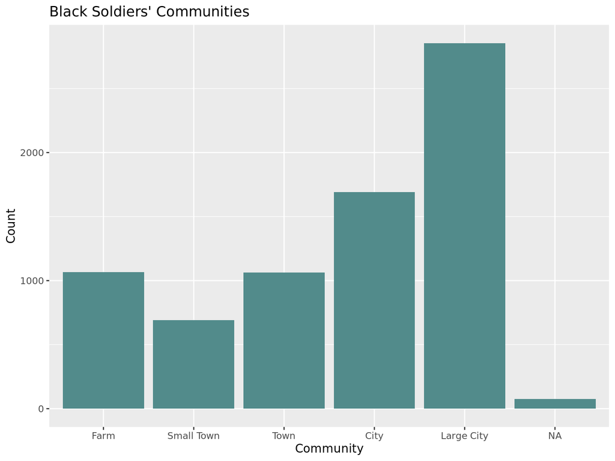

## Deeper relationships

Of course, we are interested in seeing how these variables intearct with one another to underdstand and reveal any deeper inticracies in the data.

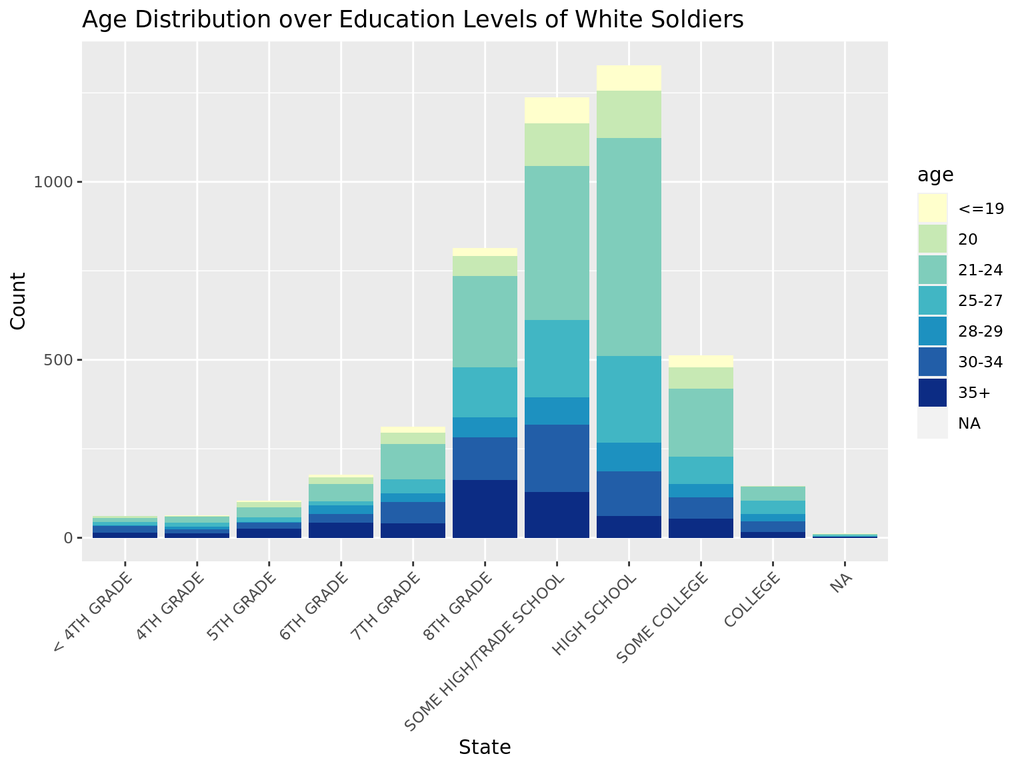

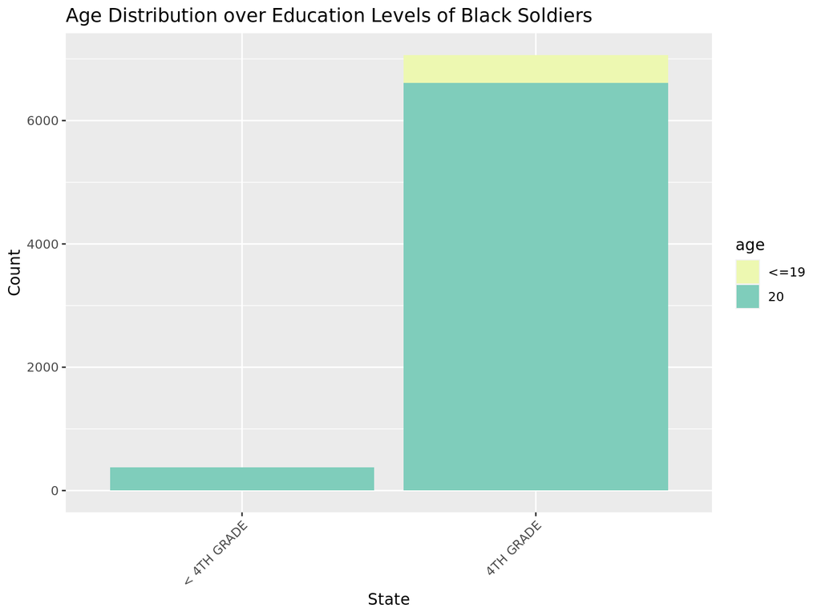

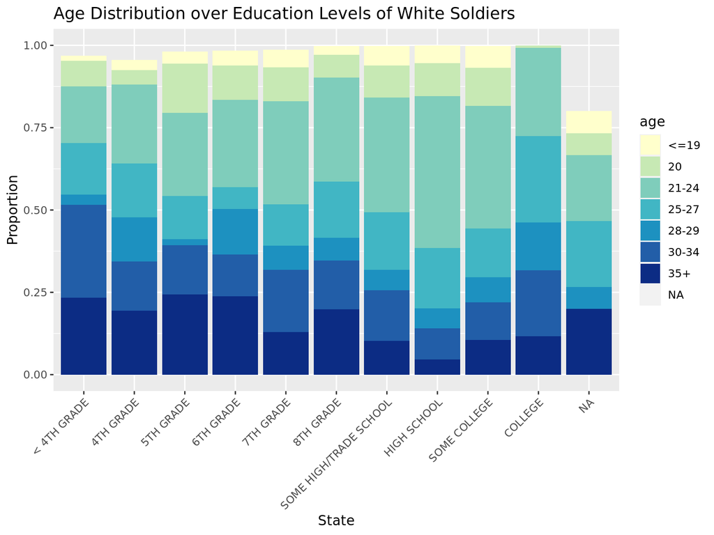

[figure not shown]

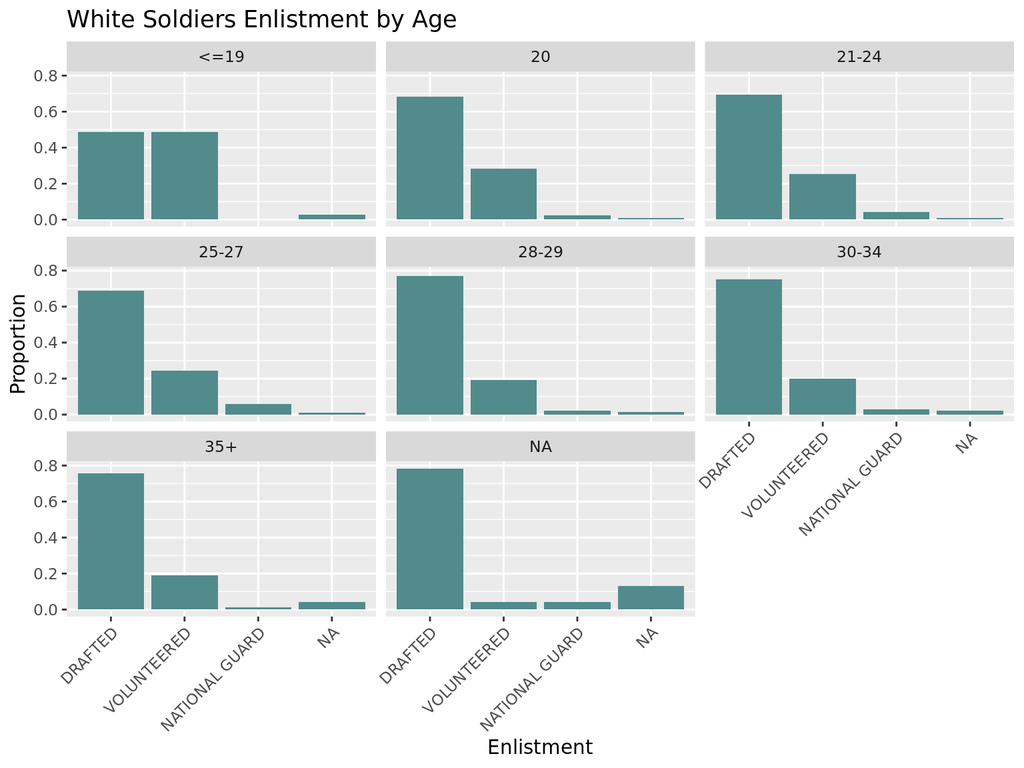

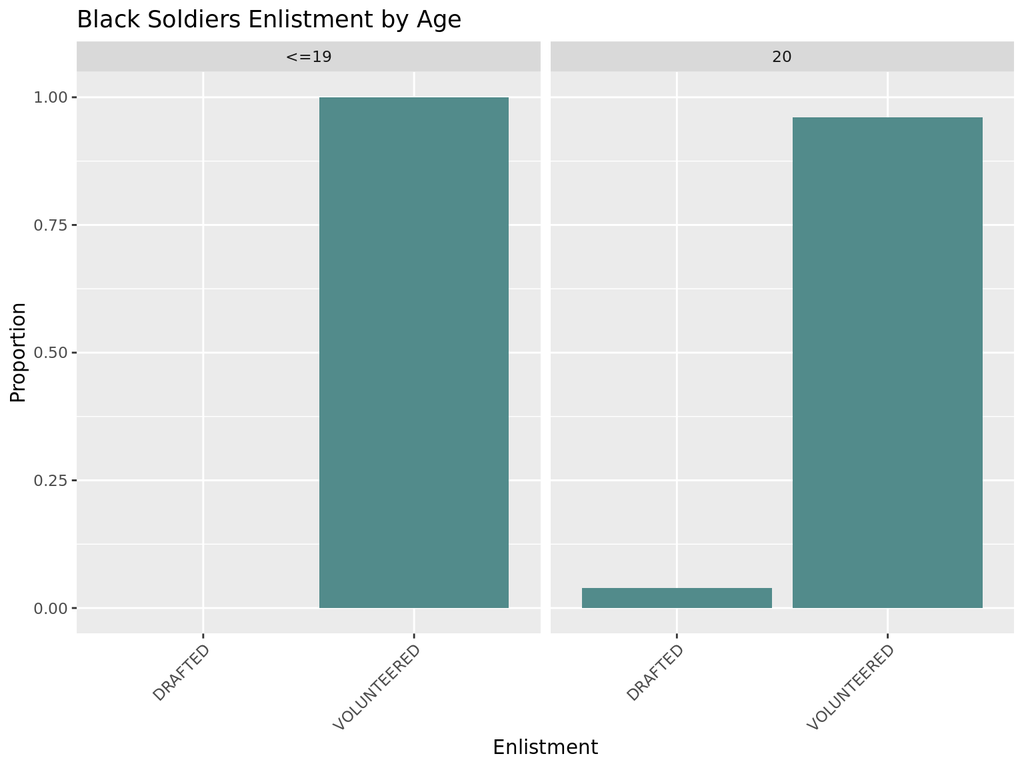

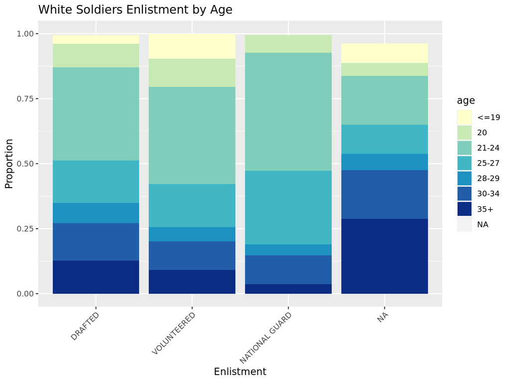

[figure not shown]